# Simpsons Episodes Analysis

Richard Luu

# Data Source

- Data obtained from [Kaggle](https://www.kaggle.com/datasets/jonbown/simpsons-episodes-2016), but author does not mention where came from / how obtained
- Upon research, it’s a mix of both Wikipedia and IMDb (Internet Movie Database)
  - Prime example being viewership and production code from Wikipedia
  - While `imdb_ratings` explicit from IMDb (for obvious reasons)
- While investigating, Wikipedia also has Nielsen ratings
  - Can scrape and do t-tests to compare whether or not Nielsen ratings significantly different from IMDb

# Exploratory Data Analysis

## Observations

```r
dim(simpsons)
```

```
## [1] 725  12
```

```r
names(simpsons)
```

```
##  [1] "id"                     "title"                  "description"
##  [4] "original_air_date"      "production_code"        "directed_by"
##  [7] "written_by"             "season"                 "number_in_season"
## [10] "number_in_series"       "us_viewers_in_millions" "imdb_rating"
```

```r
summary(simpsons)
```

```
##        id         title           description        original_air_date
##  Min.   :  0   Length:725         Length:725         Min.   :1989-12-17
##  1st Qu.:181   Class :character   Class :character   1st Qu.:1997-10-26
##  Median :362   Mode  :character   Mode  :character   Median :2005-11-27
##  Mean   :362                                         Mean   :2006-01-04
##  3rd Qu.:543                                         3rd Qu.:2014-03-16
##  Max.   :724                                         Max.   :2022-05-22
##  production_code    directed_by         written_by            season
##  Length:725         Length:725         Length:725         Min.   : 1.00
##  Class :character   Class :character   Class :character   1st Qu.: 9.00
##  Mode  :character   Mode  :character   Mode  :character   Median :17.00
##                                                           Mean   :16.94
##                                                           3rd Qu.:25.00
##                                                           Max.   :33.00
##  number_in_season  number_in_series us_viewers_in_millions  imdb_rating
##  Min.   :   1.00   Min.   :     1   Length:725             Min.   :4.000
##  1st Qu.:   6.00   1st Qu.:   182   Class :character       1st Qu.:6.600
##  Median :  12.00   Median :   363   Mode  :character       Median :7.100
##  Mean   :  15.98   Mean   :  3123                          Mean   :7.166
##  3rd Qu.:  17.00   3rd Qu.:   544                          3rd Qu.:7.700
##  Max.   :1920.00   Max.   :712713                          Max.   :9.300
```

```r
sum(is.na(simpsons))
```

```
## [1] 0
```

```r
head(simpsons) %>% rmarkdown::paged_table()
```

| id | title | description | original_air_date | production_code | directed_by | written_by | season | number_in_season | number_in_series | us_viewers_in_millions | imdb_rating |
| --- | --- | --- | --- | --- | --- | --- | --- | --- | --- | --- | --- |
| 0 | Simpsons Roasting on an Open Fire | Homer is forced to become a department store Santa when Marge spends the family's Christmas savings on removing Bart's tattoo. | 1989-12-17 | 7G08 | David Silverman | Mimi Pond | 1 | 1 | 1 | 26.7 | 8.1 |
| 1 | Bart the Genius | Bart ends up at a school for gifted children after cheating on an IQ test. | 1990-01-14 | 7G02 | David Silverman | Jon Vitti | 1 | 2 | 2 | 24.5 | 7.7 |
| 2 | Homer's Odyssey | After losing his job, Homer contemplates ending it all, until he discovers a new life path as a safety advocate. | 1990-01-21 | 7G03 | Wesley Archer | Jay Kogen & Wallace Wolodarsky | 1 | 3 | 3 | 27.5 | 7.3 |
| 3 | There's No Disgrace Like Home | After being embarrassed by the rest of the family at a company picnic, Homer becomes obsessed with improving their behavior towards each other. | 1990-01-28 | 7G04 | Gregg Vanzo & Kent Butterworth | Al Jean & Mike Reiss | 1 | 4 | 4 | 20.2 | 7.7 |
| 4 | Bart the General | After being beaten up by Nelson Muntz one too many times, Bart turns to Grampa for help, and soon leads a rebellion against the school bully. | 1990-02-04 | 7G05 | David Silverman | John Swartzwelder | 1 | 5 | 5 | 27.1 | 7.9 |
| 5 | Moaning Lisa | A depressed Lisa's spirit is lifted when she meets a jazz-man, Bleeding Gums Murphy. | 1990-02-11 | 7G06 | Wesley Archer | Al Jean & Mike Reiss | 1 | 6 | 6 | 27.4 | 7.6 |

```r
summary(simpsons$length_description)
```

```
##    Min. 1st Qu.  Median    Mean 3rd Qu.    Max.
##    5.00   18.00   23.00   23.92   28.00   98.00
```

- Most variables are in some way viable as predictor variable
  - i.e. Use description text for text analysis (frequency, sentiment, etc.) as opposed to completely ignoring
- No variable for episode run time (Can assume ~22 mins per avg run time for 30 minute tv slot)
- Does air date include time slot? (Relevance being primetime, [Friday death slot](https://en.wikipedia.org/wiki/Friday_night_death_slot) for low rating shows pending cancellation)
  - Upon further inspection, not relevant
- Rating will be most interesting to analyze/use as independent variable
- Variables changed for ease of access
  - `imdb_rating` to `rating`
  - `us_viewers_in_millions` to `viewers`
- Adding two new variables:
  - `length_description` and `age` (Time since original air date)
    - At time of starting this analysis, Season 34 has already started airing so if any episode `age` analysis is conducted will be based off this date as newer seasons [start around this time](https://en.wikipedia.org/wiki/List_of_The_Simpsons_episodes)
    - Shortest episode description is 5 words:

    ```r
    simpsons$description[which(simpsons$length_description == 5)]
    ```

    ```
    ## [1] "Marge becomes a real-estate agent."
    ## [2] "Marge accidentally gets breast implants."
    ## [3] "Fat Tony becomes Maggie's godfather."
    ```

Potential errors in data based off summary:

1. Error in `number_in_series` (Max 712713)
2. Number episode in season (Max 1920)
3. No blatant missing values but some numeric values listed as different type
- (`us_viewers_in_million`) is `char` type

Refer to README for other preliminary questions

- Misc:
  - Potential filter data by:
    - Treehouse of Horror
    - First and last episode of season
  - New external data points to consider:
    - Disney acquisition of Hulu / Fox and FX
      - Fox: March 19, 2019
      - “In March 2019, Disney acquired 21st Century Fox, giving it a 60% majority stake in Hulu” https://en.wikipedia.org/wiki/Hulu#Disney_majority_ownership
    - Sociopolitical/culture events (i.e. Presidental election episodes)
    - Simpsons movie release date: July 27, 2007

## Data Error Discussion

### A. Number In Series

```r
rmarkdown::paged_table(head(arrange(simpsons, desc(number_in_series))))
```

| id | title | description | original_air_date | production_code | directors | writers | season | number_in_season | number_in_series | us_viewers_in_millions | rating | length_description | age |
| --- | --- | --- | --- | --- | --- | --- | --- | --- | --- | --- | --- | --- | --- |
| 709 | A Serious Flanders" (Parts 1 & 2) | Homer and Ned get sucked into the violent world of prestige TV when a ruthless debt collector comes to Springfield. | 2021-11-07 | QABF21QABF22 | Debbie Bruce MahanMatthew Faughnan | Cesar Mazariegos | 33 | 67 | 712713 | 3.47 | 8.2 | 20 | 327.1667 days |
| 679 | Warrin' Priests" (Parts One and Two) | Reverend Lovejoy investigates the mysterious past of a new priest who's come to town and shaken things up at church. | 2020-04-26 | ZABF12ZABF13 | Bob AndersonMatthew Nastuk | Pete Holmes | 31 | 1920 | 681682 | 1.35 | 6.0 | 20 | 887.1667 days |
| 607 | The Great Phatsby" (Vol. I & Vol. II) | Mr Burns tries to relive his glory days, and crosses paths with a mysterious music mogul. | 2017-01-15 | WABF04WABF05 | Chris ClementsTimothy Bailey | Dan GreaneyMatt Selman (part 2 only) | 28 | 1213 | 608609 | 6.90 | 6.1 | 16 | 2084.1667 days |
| 724 | Poorhouse Rock | Grampa reconnects with an old associate in the hamburger business. | 2022-05-22 | UABF14 | Jennifer Moeller | Tim Long | 33 | 22 | 728 | 0.93 | 5.8 | 10 | 131.1667 days |
| 723 | Meat Is Murder | Marge bonds with Bart when she discovers a secret from her past, terrifying Homer. | 2022-05-15 | UABF13 | Bob Anderson | Michael Price | 33 | 21 | 727 | 1.00 | 6.7 | 14 | 138.1667 days |
| 722 | Marge the Meanie | Lisa finds an unlikely mentor in Shauna Chalmers when she joins the high school marching band; Homer becomes a craft beer brewer. | 2022-05-08 | UABF15 | Timothy Bailey | Megan Amram | 33 | 20 | 726 | 0.85 | 6.6 | 22 | 145.1667 days |

```r
subsetDF <- c("id", "title", "production_code", "directors", "writers", "number_in_season", "number_in_series")
simpsons_sub <- simpsons[,subsetDF]
#head(simpsons_sub)
#rmarkdown::paged_table(head(simpsons_sub))
```

- Sorted by max `number_in_series` in which reveals there cases where records were wrong
  - Number in series: 607, 679, 709
  - Other columns also stood out, and subsetted accordingly for further investigation

```r
subsetDF
```

```
## [1] "id"               "title"            "production_code"  "directors"
## [5] "writers"          "number_in_season" "number_in_series"
```

### B. Number in Season

```r
#simpsons[which.max(simpsons$number_in_season),]
#head(arrange(simpsons, desc(number_in_season)))
rmarkdown::paged_table(head(arrange(simpsons_sub, desc(number_in_season))))
```

| id | title | production_code | directors | writers | number_in_season | number_in_series |
| --- | --- | --- | --- | --- | --- | --- |
| 679 | Warrin' Priests" (Parts One and Two) | ZABF12ZABF13 | Bob AndersonMatthew Nastuk | Pete Holmes | 1920 | 681682 |
| 607 | The Great Phatsby" (Vol. I & Vol. II) | WABF04WABF05 | Chris ClementsTimothy Bailey | Dan GreaneyMatt Selman (part 2 only) | 1213 | 608609 |
| 709 | A Serious Flanders" (Parts 1 & 2) | QABF21QABF22 | Debbie Bruce MahanMatthew Faughnan | Cesar Mazariegos | 67 | 712713 |
| 127 | Who Shot Mr. Burns? - Part I | 2F16 | Jeffrey Lynch | Bill Oakley &Josh Weinstein | 25 | 128 |
| 152 | Summer of 4 Ft. 2 | 3F22 | Mark Kirkland | Dan Greaney | 25 | 153 |
| 177 | The Secret War of Lisa Simpson | 4F21 | Mike B. Anderson | Richard Appel | 25 | 178 |

- Two errors where the episode number in season is over 1k
- Interesting to note that both eps are also wrong in `num_in_series`
  - Assuming the data is scrapped off of Wikipedia, upon further inspection they are 2-part episode(s) (also noted by episode title)
    - Scrapped to where information is concatenated together
      - i.e.`number_in_season` is `1213`
        - 2 part episode, of episodes 12 and 13 respectively
      - Note: Episode 13 does not *officially* exist
      - If need to reference by `number_in_series` use `id`, however `number_in_season` adjusted accordingly as two episodes
    - Noted in episode titles, multiple writers, and different production codes data differs

### C. Viewers

```r
simpsons$viewers <- as.numeric(simpsons$us_viewers_in_millions)
which(is.na(as.numeric(simpsons$viewers)))
```

```
## [1] 160 161 173
```

```r
simpsons[c(160, 161, 173),c("us_viewers_in_millions", "viewers")]
```

```
## # A tibble: 3 × 2
##   us_viewers_in_millions viewers
##   <chr>                    <dbl>
## 1 N/A                         NA
## 2 N/A                         NA
## 3 N/A                         NA
```

- Simply refactor by `as.numeric()` for further application
- Missing data points, originally missed because of type issue
  - `is.na()` didn’t detect because it was of class `char`
  - Data is missing from Wikipedia
    - Interesting observation made – Wikipedia articles report viewership in both (presumed) individual viewers and viewing households
      - i.e. Compare the table of episode / viewer to individual episode rating under reception for Nielsen rating and viewing households
      - Ratio comparing existing data of viewers to viewing household came to be about 1.7-8:1 (for case of season 8)
  - Season: 8, Episode(s): 7,8,20
- Multiple ways to treat missing data for forecasting: -https://data.library.virginia.edu/getting-started-with-multiple-imputation-in-r/
  - Will try all 3, will start out with deleting missing rows.
  - Noted mean calculations earlier can be used for method 2.
  - Inputation will use other packages.
- Since it’s a two-part episode that premiered together, can assume same concurrent viewers for both part on same date
- Raises issue of should the episodes be treated separately as different parts, or one whole? For sake of consistency, they will be two separate entities (since they have different writers and production codes)

## Graphs

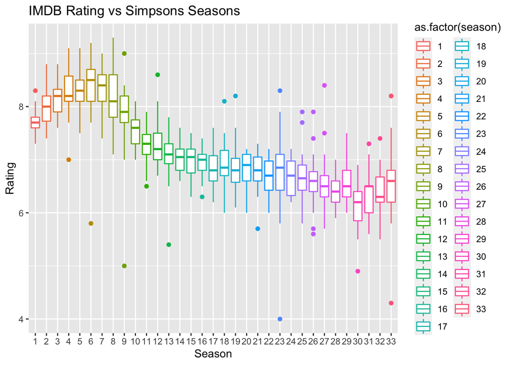

```r
(ggplot(data = simpsons, aes(x = as.factor(season), y = rating, color=as.factor(season))) + geom_boxplot() + ggtitle("IMDB Rating vs Simpsons Seasons")) + xlab("Season") + ylab("Rating")
```

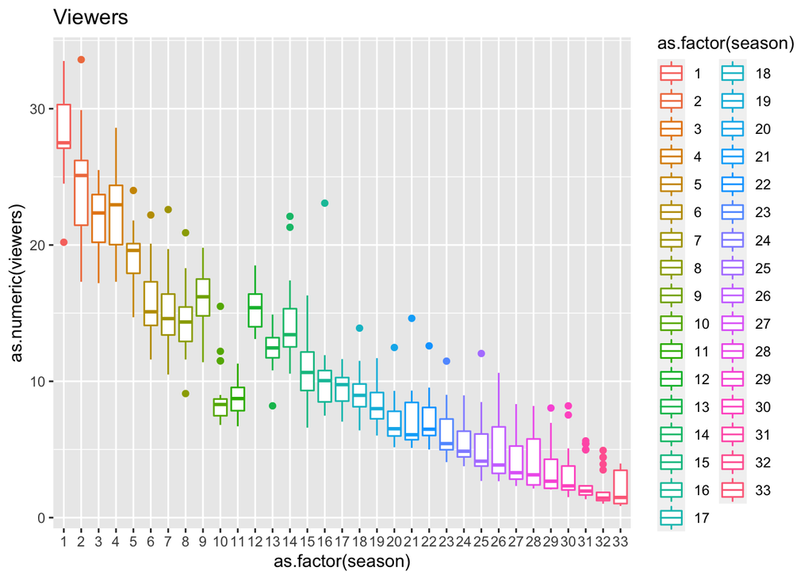

```r
#tapply(simpsons$rating, simpsons$season, summary)
(ggplot(data = simpsons, aes(x = as.factor(season), y = as.numeric(viewers), color=as.factor(season))) + geom_boxplot() + ggtitle("Viewers"))
```

Note: Graphs expected to fall under time series analysis, and using id/original_air_date/age are interchangeable since they are effectively factors/‘categorical.’

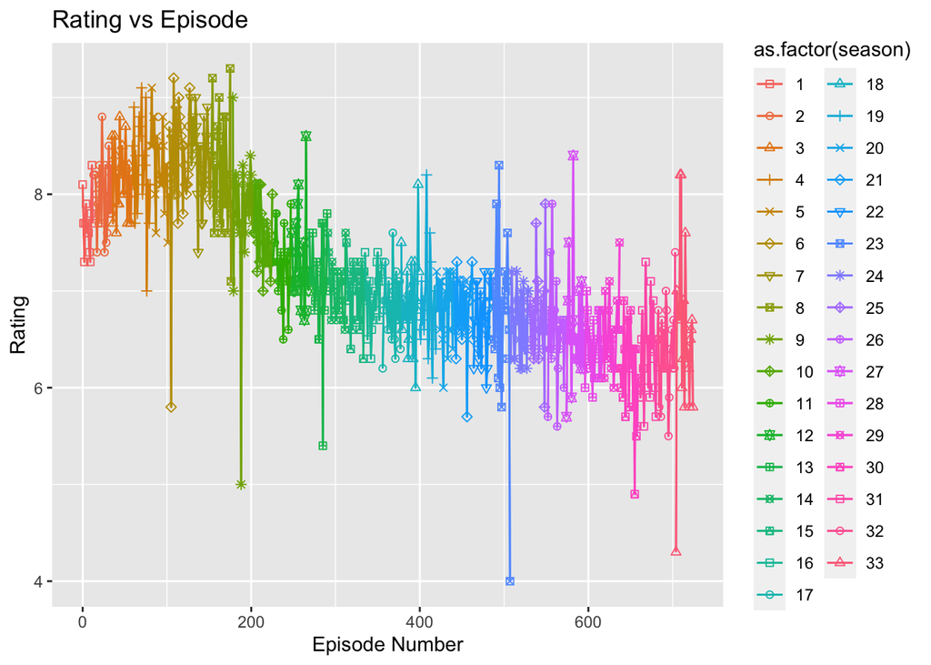

```r
(tempPlot <- ggplot(data = simpsons, aes(x = id, y = rating, col = as.factor(season), shape=as.factor(season))) +
  geom_point() + ylab("Rating") + xlab("Episode Number") + ggtitle("Rating vs Episode") +
  geom_line() + geom_line() +
  scale_shape_manual(values = rep(0:14, 3)))
```

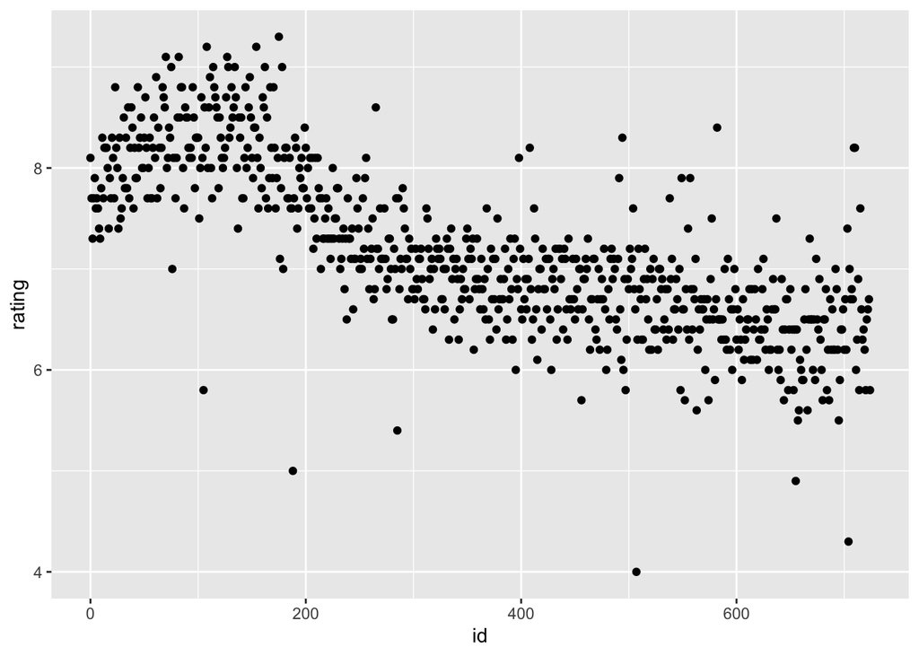

```r
ggplot(data = simpsons, aes(x=id, y = rating)) + geom_point()
```

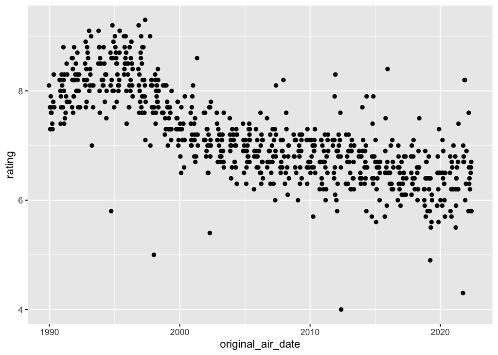

```r
ggplot(data = simpsons, aes(x=original_air_date, y = rating)) + geom_point()
```

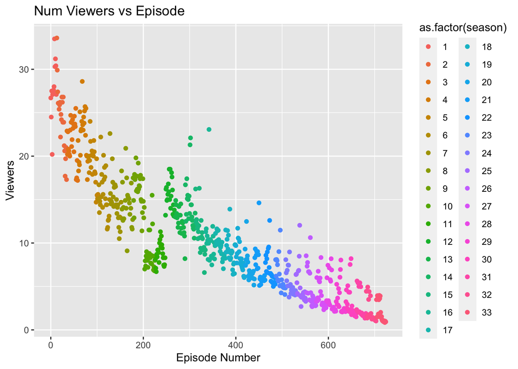

```r
(oldViewers <- ggplot(data = simpsons, aes(x = id, y = viewers, col = as.factor(season))) +
  geom_point() + ylab("Viewers") + xlab("Episode Number") + ggtitle("Num Viewers vs Episode"))
```

- ~Changing predictor variable to viewer count is interesting as pattern does not match way I thought it would~
  - ~i.e. Lower ratings = lower viewer, but need to reflect about how sample size would affect ratings~
  - Viewer count is in *millions*
  - ~Maybe an on/off season schedule? (Spring/Summer vs Fall/Winter)~
  - NOTE: Some data is missing are some `us_viewers_in_millions` values hard-coded as `N/A` (char class)
    - 159, 160, 172

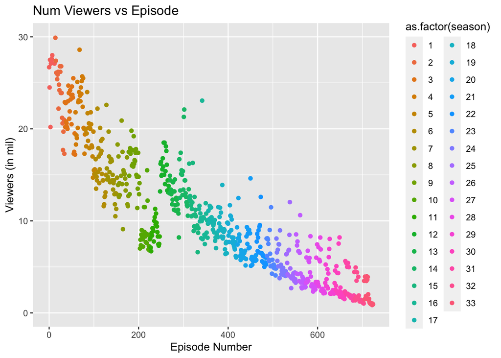

```r
simpsons$viewers <- as.numeric(simpsons$viewers)
(refactoredViewer <- ggplot(data = simpsons, aes(x = id, y = viewers, col = as.factor(season))) +
  geom_point() + ylab("Viewers") + xlab("Episode Number") + ggtitle("Num Viewers vs Episode") +
  scale_y_continuous(name="Viewers (in mil)", limits=c(0,30)))
```

- Upon refactoring viewer count to numeric trend does indeed follow expectations

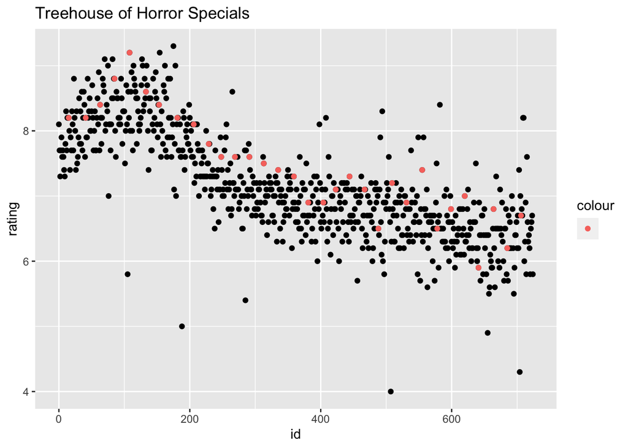

```r
#special_eps < simpsons %>% filter(simpsons, number_in_series = [4, 50, 20, 203])
THOH <- simpsons %>% filter(str_detect(title, 'Treehouse of Horror'))
ggplot(data = simpsons, aes(x = id, y = rating)) + geom_point() +
  geom_point(data = THOH, aes(x = id, y = rating, col = "")) +
  ggtitle("Treehouse of Horror Specials")
```

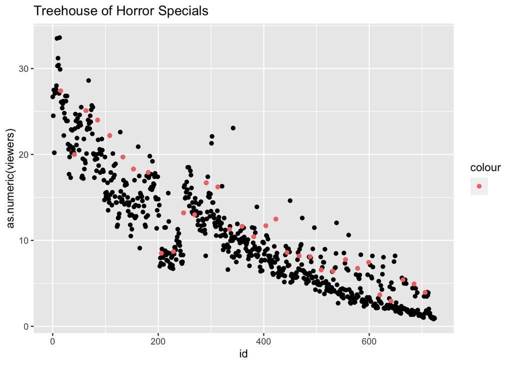

```r
ggplot(data = simpsons, aes(x = id, y = as.numeric(viewers))) + geom_point() +
  geom_point(data = THOH, aes(x = id, y = as.numeric(viewers), col = "")) +
  ggtitle("Treehouse of Horror Specials")
```

### Seasonal Data EDA (+ Season length span)

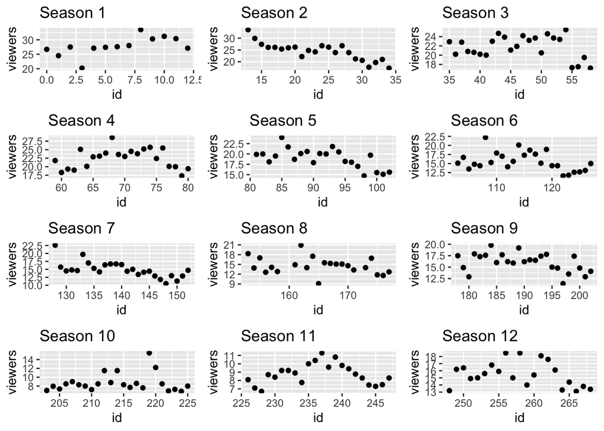

```r
get_season <- function(season_num) {
  tempDF <- simpsons %>% filter(season == season_num)
  return(tempDF)
}

s8 <- get_season(8)

set1 <- c()
set2 <- c()
set3 <- c()
# j
# plot_data_column = function (data) {
#     ggplot(data, aes_string(x = number_in_season, y = as.numeric(us_viewers_in_millions))) +
#         geom_point()
# }
#
# myplots <- lapply(1:12, plot_data_column, data = get_season(i))

for (i in 1:12) {
  temp <- get_season(i)
  tempGG <- ggplot(temp, aes(x = id, y = viewers)) + geom_point() +
    ggtitle(glue('Season {i}'))
  set1[[i]] = tempGG
}

tempIndex = 1
for (i in 13:24) {
  temp <- get_season(i)
  tempGG <- ggplot(temp, aes(x = id, y = viewers)) + geom_point() +
    ggtitle(glue('Season {i}'))
  set2[[tempIndex]] = tempGG
  tempIndex = tempIndex + 1
}

tempIndex = 1
for (i in 24:max(simpsons$season)) {
  temp <- get_season(i)
  tempGG <- ggplot(temp, aes(x = id, y = viewers)) + geom_point() +
    ggtitle(glue('Season {i}'))
  set3[[tempIndex]] = tempGG
  tempIndex = tempIndex + 1
}

# grid.arrange(set1[[1]], set1[[2]], set1[[3]], set1[[4]], ncol=2, nrow=2)

grid.arrange(grobs = set1, ncol = 3, nrow=4)
```

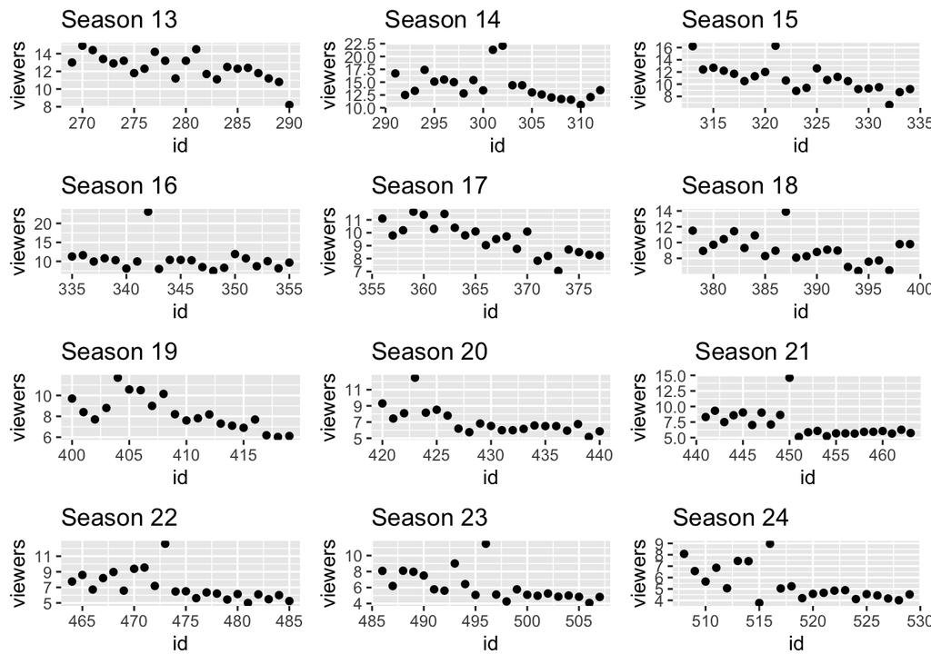

```r
grid.arrange(grobs = set2, ncol = 3, nrow=4)
```

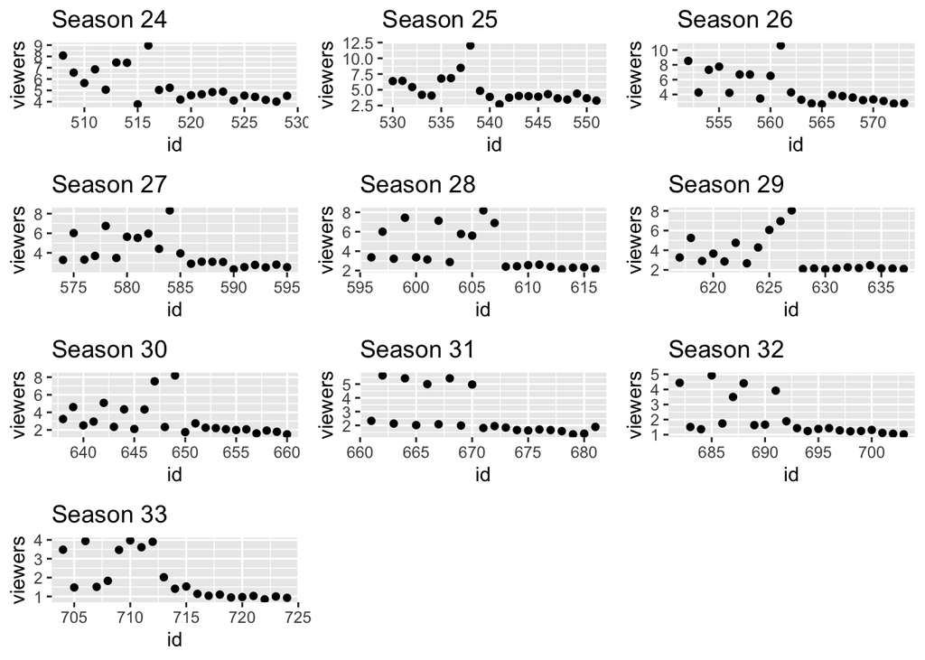

```r
grid.arrange(grobs = set3, ncol = 3, nrow=4)
```

```r
#
# for (i in 1:10) {
#   print(set1[i])
# }
# s1 <- get_season(1)
# ggplot(s1, aes(x = id, y = as.numeric(us_viewers_in_millions))) + geom_point()
# head(s1)
```

## Writers / Directors

```r
length(unique(simpsons$writers))
```

```
## [1] 183
```

```r
length(unique(simpsons$directors))
```

```
## [1] 57
```

```r
mean(nchar(simpsons$writers))
```

```
## [1] 16.6069
```

[figure not shown]

```r
avgWriter <- simpsons[which(nchar(simpsons$writers) > 16.6069 ),]

ggplot(simpsons, aes(writers, fill = writers)) + geom_bar() +
  coord_polar("y", start = 0)
```

#———————-

# Misc Resources

- [strsplit()](https://stackoverflow.com/questions/8920145/count-the-number-of-all-words-in-a-string)
- [Collapsable Elements](https://stackoverflow.com/questions/52576626/rmarkdown-collapsible-panel)
- [paged_table()](https://stackoverflow.com/questions/23188900/display-print-all-rows-of-a-tibble-tbl-df)